# - Fatal Police Shootings -

# Welcome to our Tutorial!

Authors: Jonelle Bowen, Amber Erickson, Stefani Moore

# Introduction

Data Science is an increasingly popular discipline which is focused on using methods and scientific approaches to uncover useful insights from a given pool of data. Data comes in all forms, many of which are unideal, so in this tutorial, we'll take you through the full data science pipeline which involves gathering and cleaning data, doing some exploratory data analysis which will allow us to come up with some curious hypotheses, and testing out hypotheses using machine learning.

[figure not shown]

# Tutorial Goals

Over the past few years, we've seen many instances on the news or social media of civilians being shot and killed by police officers in the line of duty. Having found an interesting dataset from https://www.kaggle.com/washingtonpost/police-shootings we're going to apply our data science methods to see if we can uncover any interesting patterns in these instances of police shootings. We think this is an especially interesting topic to analyze given the increased emphasis on police surveillance and accountability. The data was collected by the Washington Post and comprises every fatal shooting by police officers since January 1, 2015 to December 13, 2017

# Getting Started

To analyze and gain insight from the police shooting data, we'll be processing the data using the programming language, Python and the various Python libraries that will make our data manipulation much easier. These include:

**Pandas** (provides a flexible data structure known as a "Data Frame") https://pandas.pydata.org/pandas-docs/stable/

**Numpy** (used for scientific computing): http://www.numpy.org/

**Matplotlib** (used for plotting and generating graphs): https://matplotlib.org/

# Initial Set-up

We'll need to inport the following Python libraries/packages in order to proceed

```python
# for data processing/manipulation
import numpy as np
import pandas as pd
import datetime as dt

# for data visualization
import matplotlib.pyplot as plt
import folium, json
from matplotlib.dates import  DateFormatter

import warnings
warnings.filterwarnings('ignore')
```

# Data Collection

First, we will need to download the police shooting data, which can be downloaded from https://www.kaggle.com/washingtonpost/police-shootings/data . The data will come in the form of a csv file. Now, we'll need to pull the data from our csv file into a **Pandas DataFrame** which will allow us to view the table in a human-friendly table format as well as to easily manipulate the data for better analysis

```python
# pulling our data into a pandas dataframe
shootings_df = pd.read_csv("police_shootings_2.csv")

# displaying the first few rows of our data
shootings_df.head()
```

|  | id | name | date | manner_of_death | armed | age | gender | race | city | state | signs_of_mental_illness | threat_level | flee | body_camera |
| --- | --- | --- | --- | --- | --- | --- | --- | --- | --- | --- | --- | --- | --- | --- |
| 0 | 3 | Tim Elliot | 2015-01-02 | shot | gun | 53.0 | M | A | Shelton | WA | True | attack | Not fleeing | False |
| 1 | 4 | Lewis Lee Lembke | 2015-01-02 | shot | gun | 47.0 | M | W | Aloha | OR | False | attack | Not fleeing | False |
| 2 | 5 | John Paul Quintero | 2015-01-03 | shot and Tasered | unarmed | 23.0 | M | H | Wichita | KS | False | other | Not fleeing | False |
| 3 | 8 | Matthew Hoffman | 2015-01-04 | shot | toy weapon | 32.0 | M | W | San Francisco | CA | True | attack | Not fleeing | False |
| 4 | 9 | Michael Rodriguez | 2015-01-04 | shot | nail gun | 39.0 | M | H | Evans | CO | False | attack | Not fleeing | False |

## Data Tidying

We want our data to be uniform and standardized for processing because data often starts off messy. The first thing we will do is create a standard way of representing any missing information by replacing it with 'Unknown'.

For further analysis on any potential relationship between the fatal shootings and the dates, we will convert each date string to a datetime object. DateTime is a standard way of representing dates, which is provided through a Python library. For further information, refer to: https://docs.python.org/2/library/datetime.html

```python
# changing each cell in the date column to datetime objects to make analysis by dates easier
shootings_df['date'] = pd.to_datetime(shootings_df['date'])

#dropping unecessary data
shootings_df = shootings_df.drop(['name', 'manner_of_death', 'armed', 'age', 'city' ,'signs_of_mental_illness', 'threat_level', 'flee'], axis=1)

# holds indices of rows to be dropped (2017-12)
to_drop = []

# iterate through all entries to replace 'NaN' values with a more intuitive one,'Unknown'
for i, row in shootings_df.iterrows():
    # NaN is equivalent to null
    if (pd.isnull((row['race']))):
        shootings_df.set_value(i, 'race', 'Unknown')
    if (pd.isnull((row['gender']))):
        shootings_df.set_value(i, 'gender', 'Unknown')
    if(row['date'].year == 2017 and row['date'].month == 12):
        to_drop.append(i)

# deleting all the date from December 2017 as it is incomplete
shootings_df = shootings_df.drop(to_drop, axis=0)

# rearranging the columns
shootings_df = shootings_df.reindex_axis(['id', 'date', 'state', 'race', 'gender', 'body_camera'], axis=1)

# the resulting data
shootings_df.head()
```

|  | id | date | state | race | gender | body_camera |
| --- | --- | --- | --- | --- | --- | --- |
| 0 | 3 | 2015-01-02 | WA | A | M | False |
| 1 | 4 | 2015-01-02 | OR | W | M | False |
| 2 | 5 | 2015-01-03 | KS | H | M | False |
| 3 | 8 | 2015-01-04 | CA | W | M | False |
| 4 | 9 | 2015-01-04 | CO | H | M | False |

## Exploratory Data Analysis

Now let's see if we can find any trends in our data to provide some insight. We will produce some visualizations using the Matplotlib library to uncover any trends in the data.

#### Some questions we might want to ask:

1. Have police shootings gone up or down since body cams were implemented in 2015?
2. Is race a determining factor?
3. Are killings more prevalent in states that implemented body cams versus the ones that did not?

### 1. State Distribution

By inpecting the data, we noticed that some states had a higher number of shootings. This could be explained by the differences in state populations. To eliminate population size influences on the results, we gathered extra data on state populations. The data can be found on this webisite: http://worldpopulationreview.com/states/.

We start by getting the data we have on the number of shootings per state.

```python
# retrieving the number of shootings per state
shootings_per_state = shootings_df.groupby('state').id.count().reset_index()
shootings_per_state = shootings_per_state.rename(columns={'id' : 'num_shootings'})

# calculating the proportional percentage of shootings with respect to population size
shootings_per_state['num_shootings'] = shootings_per_state['num_shootings']


shootings_per_state.head()
```

|  | state | num_shootings |
| --- | --- | --- |
| 0 | AK | 17 |
| 1 | AL | 64 |
| 2 | AR | 30 |
| 3 | AZ | 134 |
| 4 | CA | 477 |

Next, some data manipulation is required to combine the state population and the state shootings as the two datasets come from different sources.

```python
# reading the population estimates by state
state_pop_df = pd.read_csv("state_population_estimate.csv")

# reading map of state name and their abreviations
state_abrev = pd.read_csv("states_abrev.csv")

state_pop_df = pd.merge(state_pop_df, state_abrev, on='State', how='inner')
state_pop_df = state_pop_df.drop(['State','2017 Growth'], axis=1)
state_pop_df = state_pop_df.rename(columns={'Abbreviation' : 'state'})

# mergin th number of shootings data we have with the states population estimates
state_pop_df = pd.merge(state_pop_df, shootings_per_state, on = 'state', how = "inner")

# tidying the data by dropping unecessary columns and rearrenging another
state_pop_df = state_pop_df.drop(['% of US','Rank'], axis=1)
state_pop_df = state_pop_df.reindex_axis(['state', '2017 Population', 'num_shootings'], axis=1)

# the resulting data
state_pop_df.head()
```

|  | state | 2017 Population | num_shootings |
| --- | --- | --- | --- |
| 0 | CA | 39506094 | 477 |
| 1 | TX | 28295553 | 244 |
| 2 | FL | 20979964 | 176 |
| 3 | NY | 19743395 | 50 |
| 4 | PA | 12776550 | 59 |

Now that we have each state's population estimates and their respective number of shootings , we can calculate the proportional percentage of shootings in relation to population size.

```python
state_pop_df['shooting_percent'] = state_pop_df['num_shootings'] / state_pop_df['2017 Population'] * 100

state_pop_df.head()
```

|  | state | 2017 Population | num_shootings | shooting_percent |
| --- | --- | --- | --- | --- |
| 0 | CA | 39506094 | 477 | 0.001207 |
| 1 | TX | 28295553 | 244 | 0.000862 |
| 2 | FL | 20979964 | 176 | 0.000839 |
| 3 | NY | 19743395 | 50 | 0.000253 |
| 4 | PA | 12776550 | 59 | 0.000462 |

Now that's we've gathered this information, let's see how this looks on a map where states are colored according to its percentage of fatal shootings. Darker colored states have a higher fatal shooting percentage.

The following map is generated using a Folium, a Python library used for displaying interactive maps. See https://folium.readthedocs.io/en/latest/ for more information

```python
#Let Folium determine the scale
map = folium.Map([43,-100], zoom_start=3)

map.choropleth(
    geo_data = json.load(open("places.geojson")),
    name='choropleth',
    data=state_pop_df,
    columns=['state', 'shooting_percent'],
    key_on='feature.id',
    fill_color='OrRd',
    fill_opacity=.6,
    line_opacity=1,
    legend_name='Shootings Per State (%)'
)

folium.LayerControl().add_to(map)
map
```

[interactive chart not shown]

California had the highest number of shootings of all states while Texas had the second highest. As seen in the map above, the proportional number of shootings with respect to population size changed the distribution.

Now it is clear that the states with the highest fatalities are New Mexico, Alaska, and Oklahoma. On the other hand, California and Texas' number of shootings is comparable to the rest of the country on average.

### 2. Demographics

#### 2.1 Gender Visualization

Let's take a look at the demographics of the victms by starting with gender.

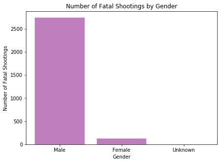

```python
# getting the number of fatal shootings for males, females and victims of unknown gender
num_males = len(shootings_df[shootings_df['gender'] == 'M'])
num_females = len(shootings_df[shootings_df['gender'] == 'F'])
num_unknown_gender = len(shootings_df[shootings_df['gender'] == 'Unknown'])

# variables for the graph
bars = ('Male', 'Female', 'Unknown')
y_pos = np.arange(len(bars))
fig, ax = plt.subplots(figsize=(7,5))

# data for each gender
num_shootings = [num_males, num_females, num_unknown_gender]

# plotting the data
plt.bar(y_pos, num_shootings, align='center', alpha=0.5, color='purple')
plt.xticks(y_pos, bars)
plt.xlabel('Gender')
plt.ylabel('Number of Fatal Shootings')
plt.title('Number of Fatal Shootings by Gender')

plt.show()
```

As shown in the above graph, most of the shooting victims are male, so it might not be very helpful to do any kind of analysis using gender as a predictive factor as it would not have much impact on the analysis.

#### 2.2 Race Visualization

Given the current social movements surrounding race relations and the current political state of the US, maybe it would be interesting to take a look at the shootings by race.

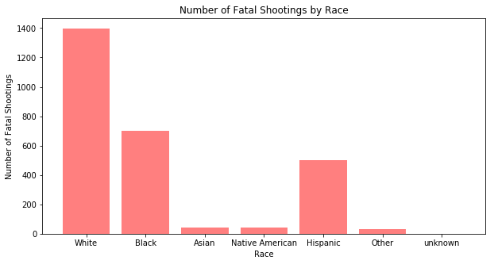

```python
# gathering the number of shootings for each race in the dataset
num_black = len(shootings_df[shootings_df['race'] == 'B'])
num_white = len(shootings_df[shootings_df['race'] == 'W'])
num_asian = len(shootings_df[shootings_df['race'] == 'A'])
num_native = len(shootings_df[shootings_df['race'] == 'N'])
num_hispanic = len(shootings_df[shootings_df['race'] == 'H'])
num_other = len(shootings_df[shootings_df['race'] == 'O'])
num_unknown_race = len(shootings_df[shootings_df['race'] == 'None'])

# variables for the graph
bars = ('White','Black','Asian','Native American','Hispanic', 'Other', 'unknown')
y_pos = np.arange(len(bars))
fig, ax = plt.subplots(figsize=(10,5))

# the data for each race
num_shootings = [ num_white, num_black, num_asian, num_native, num_hispanic, num_other, num_unknown_race]

# plotting the data
plt.bar(y_pos, num_shootings, align='center', alpha=0.5, color ="red")
plt.xticks(y_pos, bars)
plt.xlabel('Race')
plt.ylabel('Number of Fatal Shootings')
plt.title('Number of Fatal Shootings by Race')

plt.show()
```

As we can see from the chart above, the White population represents most of the observed victims of fatal police shootings, followed by the Black and Hispanic populations.

However, we need to contextualize these numbers by seeing what portion of the population each racial group represents and seeing how that compares to the number of fatal shootings for each group.

To acomplish this, we found Federal Census data on the US population to find the respective proportions of each racial group. The data can be obtained from: https://www.census.gov/quickfacts/fact/table/US/PST045216#viewtop.

```python
# storing the census data on race population
race_census_map = [['White, non-Hispanic', 198.077165469, 61.3 ],['Black, non-Hispanic', 42.975959, 13.3 ],['Asian', 18.418268,5.7],
                   ['Native American', 4.200657, 1.3], [ 'Hispanic', 57.516697, 17.8]]

# adding the data on race population to a DataFrame
race_census_df = pd.DataFrame(race_census_map, columns=['Race','Number in Population per million', 'Percentage of Population'])

# the resulting DataFrame
race_census_df
```

|  | Race | Number in Population per million | Percentage of Population |
| --- | --- | --- | --- |
| 0 | White, non-Hispanic | 198.077165 | 61.3 |
| 1 | Black, non-Hispanic | 42.975959 | 13.3 |
| 2 | Asian | 18.418268 | 5.7 |
| 3 | Native American | 4.200657 | 1.3 |
| 4 | Hispanic | 57.516697 | 17.8 |

We proceeded to calculate the approximate number of individuals in each racial group and put the data into a Pandas DataFrame.

```python
# number of shootings per race
num_white = len(shootings_df[shootings_df['race'] == 'W'])
num_black = len(shootings_df[shootings_df['race'] == 'B'])
num_asian = len(shootings_df[shootings_df['race'] == 'A'])
num_native = len(shootings_df[shootings_df['race'] == 'N'])
num_hispanic = len(shootings_df[shootings_df['race'] == 'H'])

# population data per race. To accomodate the fact that the data is in millions, we will multiply the data by 1 million
pop_W = (race_census_df['Number in Population per million'][0]) * 1000000 # 1 million
pop_B = (race_census_df['Number in Population per million'][1]) * 1000000 # 1 million
pop_A = (race_census_df['Number in Population per million'][2]) * 1000000 # 1 million
pop_N = (race_census_df['Number in Population per million'][3]) * 1000000 # 1 million
pop_H = (race_census_df['Number in Population per million'][4]) * 1000000 # 1 million

#------------------- Calculating the percentage of shootings for each race by their rescpective population estimates

percent_white = (num_white / pop_W)  * 100
percent_black = (num_black / pop_B)  * 100
percent_asian = (num_asian / pop_A)  * 100
percent_native = (num_native / pop_N)  * 100
percent_hispanic = (num_hispanic / pop_H)  * 100

total_percent = percent_white + percent_black + percent_asian + percent_native + percent_hispanic

final_white = (percent_white / total_percent) * 100
final_black = (percent_black / total_percent) * 100
final_asian = (percent_asian / total_percent) * 100
final_native = (percent_native / total_percent) * 100
final_hispanic = (percent_hispanic / total_percent) * 100
```

To better visualize the data, we will use a Pie chart.

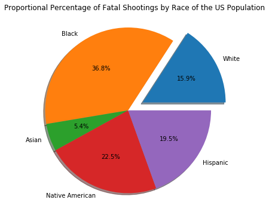

```python
# variables for the graph
bars = ('White','Black','Asian','Native American','Hispanic')
y_pos = np.arange(len(bars))
race_labels = 'White','Black','Asian','Native American','Hispanic'

# the data to be plotted
percentages = [final_white, final_black, final_asian, final_native, final_hispanic]

# plotting the data
fig1, ax1 = plt.subplots(figsize=(6,6))
ax1.pie(percentages, labels=race_labels, explode=(.2, 0, 0, 0, 0), autopct='%1.1f%%', shadow=True)
ax1.axis('equal')
plt.title('Proportional Percentage of Fatal Shootings by Race of the US Population')

plt.show()
```

### 3. Body Camera Usage

In late 2014, many police departments in the US deployed body cameras with the belief that they would help with officer accountability, reduce the use of excessive force, and aid in legal proceedings.

Three years later, people are still divided on whether the cameras were effective or a waste of taxpayers' money.

Before we can see the number of shootings over time, we need to separate the month and the year from the date column.

```python
# create new columns for month and year
shootings_df['month'] = ''
shootings_df['year'] = ''

# going over each row, and separating the date to insert into the new columns
for i, row in shootings_df.iterrows():

    if len(str(row['date'].month)) != 2:
        shootings_df.loc[i,('month')] = '0' + str(row['date'].month)
    else:
        shootings_df.loc[i,('month')] = str(row['date'].month)

    shootings_df.loc[i,('year')] = str(row['date'].year)

# dropping the date column as we no longer need the date
shootings_df = shootings_df.drop('date', axis=1)

# the resulting data
shootings_df.head()
```

|  | id | state | race | gender | body_camera | month | year |
| --- | --- | --- | --- | --- | --- | --- | --- |
| 0 | 3 | WA | A | M | False | 01 | 2015 |
| 1 | 4 | OR | W | M | False | 01 | 2015 |
| 2 | 5 | KS | H | M | False | 01 | 2015 |
| 3 | 8 | CA | W | M | False | 01 | 2015 |
| 4 | 9 | CO | H | M | False | 01 | 2015 |

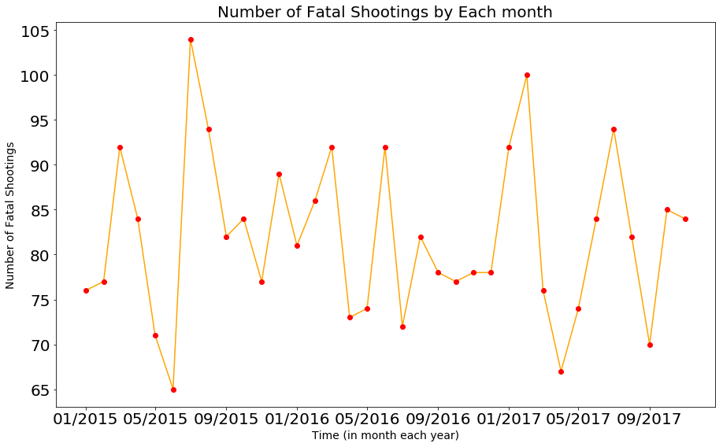

```python
#----------------- The code below is simply formating the x axis so that it is sorted by month-year
years = [2015, 2016, 2017]
month = 1
dates = []
for year in years:
    for month in np.arange(1, 13):
        if len(str(month)) == 1:
            dates.append('0' + str(month) + '/' + str(year) )

        elif year == 2017 and month == 12:
            continue
        else:
            dates.append(str(month) + '/' + str(year) )

#----------------- End of formating

#
month_year_x = [dt.datetime.strptime(d,'%m/%Y').date() for d in dates]
num_shootings_y = shootings_df.groupby(['year','month']).id.count()


fig, ax = plt.subplots(figsize=(15,9))

# can change rp to other colors or shapes
plt.plot(month_year_x,num_shootings_y, 'orange', month_year_x, num_shootings_y, 'ro')

ax.xaxis.set_major_formatter(DateFormatter('%m/%Y'))

plt.xticks(fontsize=20)
plt.yticks(fontsize=20)
plt.xlabel('Time (in month each year)', fontsize=14)
plt.ylabel('Number of Fatal Shootings', fontsize=14)
plt.title('Number of Fatal Shootings by Each month', fontsize=20)

plt.show()
```

To try and spot the trend of numbers of shootings over time and body camera efficiency, we will divide our dataset into two sets. One set will contain the data of when body cameras were used while the other will not. Then we will plot the line of shootings over time for both sets.

```python
shootings_df.describe()
```

|  | id |
| --- | --- |
| count | 2866.000000 |
| mean | 1625.568039 |
| std | 898.329610 |
| min | 3.000000 |
| 25% | 855.250000 |
| 50% | 1627.500000 |
| 75% | 2402.750000 |
| max | 3210.000000 |

```python
# retrieving the shootings when body camera was used
body_cam_df = shootings_df.loc[shootings_df['body_camera'] == True]

# retrieving the shootings when body camera was NOT used
no_body_cam_df = shootings_df.loc[shootings_df['body_camera'] == False]
```

```python
# sample random N observations that did not use body camera to match the N that did use
sample_size = len(body_cam_df)
no_body_cam_df = no_body_cam_df.sample(sample_size)
```

```python
# grouping both sets by month and date so we can plot the data
num_shootings_body_cam = body_cam_df.groupby(['year','month']).id.count()
num_shootings_no_body_cam = no_body_cam_df.groupby(['year','month']).id.count()
```

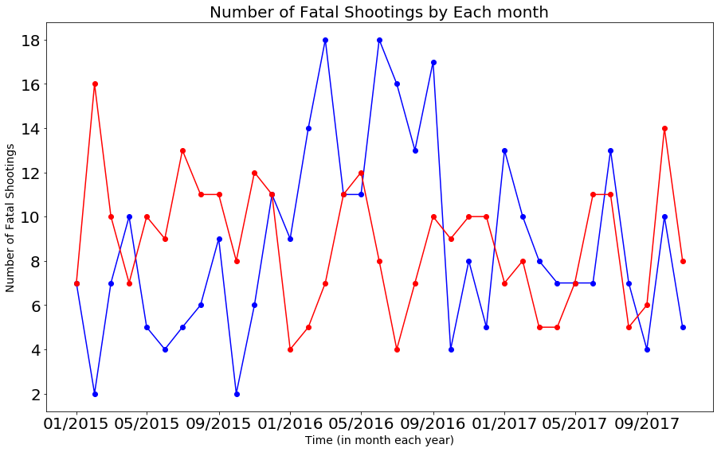

```python
fig, ax = plt.subplots(figsize=(15,9))

# can change rp to other colors or shapes
ax.plot(month_year_x, num_shootings_body_cam, 'blue', month_year_x, num_shootings_body_cam, 'bo')
ax.plot(month_year_x, num_shootings_no_body_cam, 'red', month_year_x, num_shootings_no_body_cam, 'ro')

ax.xaxis.set_major_formatter(DateFormatter('%m/%Y'))

plt.xticks(fontsize=20)
plt.yticks(fontsize=20)
plt.xlabel('Time (in month each year)', fontsize=14)
plt.ylabel('Number of Fatal Shootings', fontsize=14)
plt.title('Number of Fatal Shootings by Each month', fontsize=20)
# plt.legend(['Body Camera', 'No Body Camera'], loc='upper right')

plt.show()
```

### 3.1 Statistics

```python
body_cam_df.describe()
```

|  | id |
| --- | --- |
| count | 309.000000 |
| mean | 1686.676375 |
| std | 790.430159 |
| min | 16.000000 |
| 25% | 1188.000000 |
| 50% | 1679.000000 |
| 75% | 2286.000000 |
| max | 3174.000000 |

```python
no_body_cam_df.describe()
```

|  | id |
| --- | --- |
| count | 309.000000 |
| mean | 1547.686084 |
| std | 923.327809 |
| min | 3.000000 |
| 25% | 732.000000 |
| 50% | 1528.000000 |
| 75% | 2334.000000 |
| max | 3172.000000 |

# Machine Learning

Machine Learning will allows us to perform some predictive analysis on our data. We are interested in predicting the the number of shootings for next year for any given month when both either body cameras are in use and are not. This prediction will allow us make statistical statements about the trend of shootings for the future such as if it will decrease or increase.

We decided to separte the entire data set into two for better predictions. One set contains the data on shooting where body cameras were in use while the other contains the data where body cameras were no used.

We do this by separating the data into tranning data and testing data. The training data is used to build a model that will be used to predict unobserved values for month and year (e.g., the future). On the other hand, the test data is used to check if our model is appropriate and returns accurate results.

The function below implements the model and the model testing explained above.

```python
from sklearn import linear_model
from statsmodels.formula.api import ols
import matplotlib.dates as dt
from datetime import datetime
from sklearn.linear_model import LinearRegression
from sklearn.model_selection import KFold
from sklearn.linear_model import LinearRegression
from sklearn.model_selection import KFold

# function used to test our model
# Returns an array that
def kFold_other(K, X, y):

    regression = linear_model.LinearRegression()
    avg_train_error = 0
    kf = KFold(n_splits=K)
    errors = []

    for train, test in kf.split(X):

        x_train, y_train = X[train], y[train]
        x_test, y_test = X[test], y[test]

        regression.fit(x_train, y_train)

        predict = regression.predict(x_test)
        error = (predict - y_test) ** 2
        avg_error = np.mean(error) / K

        errors.append(avg_error)

    return errors
```

## 2. Body Camera In Use Dataset

The code below does some data manipulation so that we can perform Linear Regression on the datasets. o learn more about Linear Regression see the following: http://onlinestatbook.com/2/regression/intro.html

```python
# --------------------------- creating a datetime column for body cam dataframe
month_year = []
for idx, row in body_cam_df.iterrows():
    m_y_string = str(row['month']) + '/' + str(row['year'] )
    date = dt.date2num(datetime.strptime(m_y_string, '%m/%Y'))
    month_year.append(date)

# adding month_year column to dataframe
body_cam_df['month_year'] = month_year

# grouping the data so that we can calculate number of shootings in respect to time, state and race
num_shootings_y = body_cam_df.groupby(['month_year'], as_index=False)

# initialize a column to hold the value we calculated
body_cam_df['num_shootings_for_month'] = 0

# drop uncessary
body_cam_df = body_cam_df.drop(['id', 'gender', 'body_camera', 'year', 'month'], axis=1)

body_cam_df.head()
```

|  | state | race | month_year | num_shootings_for_month |
| --- | --- | --- | --- | --- |
| 8 | IA | W | 735599.0 | 0 |
| 14 | LA | B | 735599.0 | 0 |
| 16 | UT | W | 735599.0 | 0 |
| 18 | UT | W | 735599.0 | 0 |
| 24 | NM | W | 735599.0 | 0 |

Now we are calculating the total number of shootings per month_year.

```python
# calculate number of shootings in respect to time, state and race
temp_new_df = pd.DataFrame(columns=body_cam_df.columns)

# iterate over the grouped data and find the number of shootings for each group
for (month), df in num_shootings_y:
    rows = body_cam_df[(body_cam_df['month_year'] == month)]
    rows['num_shootings_for_month'] = df.id.count()

    # save results on the new_df
    temp_new_df = pd.concat([temp_new_df, rows], axis=0)

# rename the new df
body_cam_df = temp_new_df
```

Finally, we can build our model and perfmos our test.

```python
# the set of features we are using to build our model
X_body_cam =  body_cam_df[['month_year']].reset_index().drop('index', axis=1)

# the targests: the observed values of the dependent variable for each row in the features set
y_body_cam = pd.factorize(body_cam_df['num_shootings_for_month'])[0]

#build and test model usinf kFold cross validation
error = kFold_other(10, X_body_cam.values, y_body_cam)
```

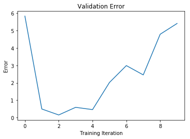

```python
#plot the results
plt.plot(error, label='Training Error')
plt.title('Validation Error')
plt.ylabel('Error')
plt.xlabel('Training Iteration')
plt.show()
```

## 2. Body Camera NOT in Use Dataset

The code below does some data manipulation so that we can perform Linear Regression on the datasets. o learn more about Linear Regression see the following: http://onlinestatbook.com/2/regression/intro.html

```python
# --------------------------- creating a datetime column for body cam dataframe
month_year = []
for idx, row in no_body_cam_df.iterrows():
    m_y_string = str(row['month']) + '/' + str(row['year'] )
    date = dt.date2num(datetime.strptime(m_y_string, '%m/%Y'))
    month_year.append(date)

# adding month_year column to dataframe
no_body_cam_df['month_year'] = month_year

# grouping the data so that we can calculate number of shootings in respect to time, state and race
num_shootings_y = no_body_cam_df.groupby(['month_year'], as_index=False)

# initialize a column to hold the value we calculated
no_body_cam_df['num_shootings_for_month'] = 0

# drop uncessary
no_body_cam_df = no_body_cam_df.drop(['id', 'gender', 'body_camera', 'year', 'month'], axis=1)

no_body_cam_df.head()
```

|  | state | race | month_year | num_shootings_for_month |
| --- | --- | --- | --- | --- |
| 1149 | AZ | H | 735995.0 | 0 |
| 2481 | OH | W | 736511.0 | 0 |
| 2529 | OH | B | 736511.0 | 0 |
| 2368 | FL | W | 736481.0 | 0 |
| 986 | MS | W | 735933.0 | 0 |

The code below does some data manipulation so that we can perform Linear Regression on the datasets.

```python
# calculate number of shootings in respect to time, state and race
temp_new_df = pd.DataFrame(columns=no_body_cam_df.columns)

# iterate over the grouped data and find the number of shootings for each group
for (month), df in num_shootings_y:
    rows = no_body_cam_df[(no_body_cam_df['month_year'] == month)]
    rows['num_shootings_for_month'] = df.id.count()

    # save results on the new_df
    temp_new_df = pd.concat([temp_new_df, rows], axis=0)

# rename the new df
no_body_cam_df = temp_new_df
```

```python
# the set of features we are using to build our model
X_nobody_cam =  no_body_cam_df[['month_year']].reset_index().drop('index', axis=1)

# the targests: the observed values of the dependent variable for each row in the features set
y_nobody_cam = pd.factorize(no_body_cam_df['num_shootings_for_month'])[0]

#build and test model usinf kFold cross validation
error_nobody_cam = kFold_other(10, X_nobody_cam.values, y_nobody_cam)
```

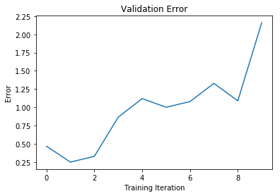

```python
#plot it
plt.plot(error_nobody_cam, label='Training Error')
plt.title('Validation Error')
plt.ylabel('Error')
plt.xlabel('Training Iteration')
plt.show()
```

## Prediction

Our hypothesis is that in July 2018 there will be less shooting if body cameras are in use.

To test our hyphothesis, we will use both models to predict the number of shootings in that month for both when body cameras are in use and are not in use.

```python
# build the datetime obt for our prediction
m_y_string = str('07' + '/' + '2018' )
date = dt.date2num(datetime.strptime(m_y_string, '%m/%Y'))

regression = linear_model.LinearRegression()
regression.fit(X_body_cam, y_body_cam)
predict = regression.predict(date)

predict
```

```
array([ 7.87465941])
```

```python
regression = linear_model.LinearRegression()
regression.fit(X_nobody_cam, y_nobody_cam)
predict = regression.predict(date)

predict
```

```
array([ 7.82352796])
```

# Conclusion

We reject our hyphothesis that in July 2018 there will be less shootings when body cameras are in use. However, after predicting the number of shootings for that date for both in use and not in use cases, we saw virtually no difference in predicted number of shootings.

This could be explained by having a poor relationship between time and the number of shootings. We could further explore relationships between race and time or age to if there is a correlation.

In addition, because body cameras are still relativally new, and may not have enough observations to give us the full picture.

Lastly, currently there is no uniform regulations regarding body camera usage. For example, the officers might be allowed to turn the camera off when they desire.

# References and Further Readings

Police shootings data:

https://www.kaggle.com/washingtonpost/police-shootings

Race and Ethnicity Codes:

https://ushik.ahrq.gov/ViewItemDetails?system=sdo&itemKey=133211000

Washington Post :

https://www.washingtonpost.com/graphics/national/police-shootings/

Further Reading:

https://news.yale.edu/2017/10/27/do-body-cameras-affect-police-officers-behavior-not-so-much

http://time.com/4771417/jordan-edwards-body-cameras-police/

https://www.nytimes.com/2017/04/26/nyregion/do-body-cameras-help-policing-1200-new-york-officers-aim-to-find-out.html

https://www.washingtonpost.com/posteverything/wp/2017/06/01/bodycams-are-key-for-police-accountability-we-cant-let-them-erode-privacy-rights/?utm_term=.afd5487551e2